# Status of Big Skate (*Beringraja binoculata*) Off the U.S. Pacific Coast in 2019

# Executive Summary

## Catches

Landings and estimated discards of Big Skate were reconstructed for this assessment from historical records of other species and from species composition data collected in the recent fishery. These reflect the fishery from 1916-1994. The current fishery started in 1995. For records from 1995-2017, Big Skate landings were estimated from species-composition samples and the landings of “Unspecified Skates”. Beginning in 2017, Big Skate have been recorded in species-specific landings.

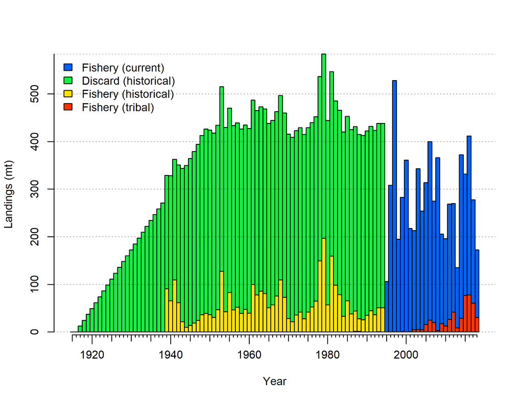

Catch history of Big Skate in the model.

## Data and Assessment

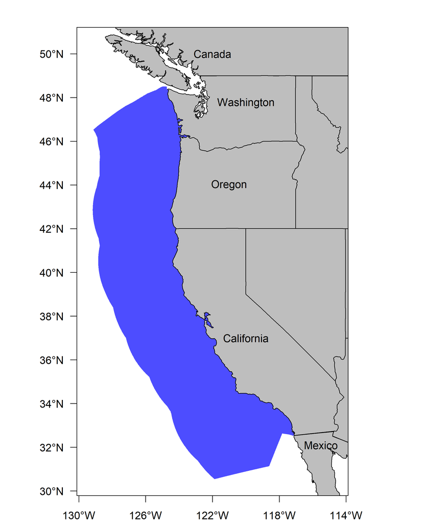

## Stock Biomass

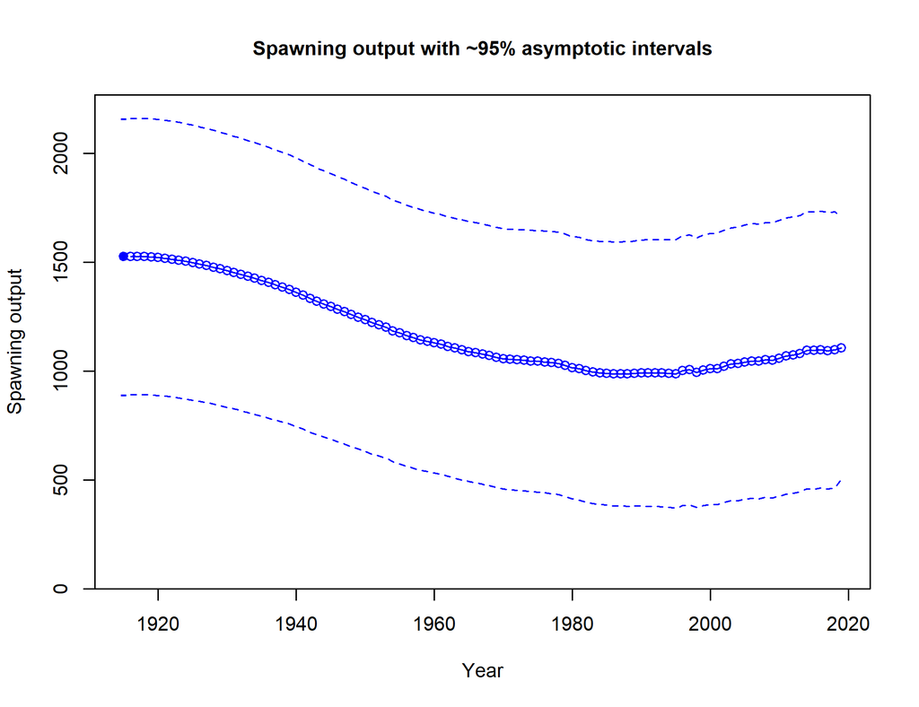

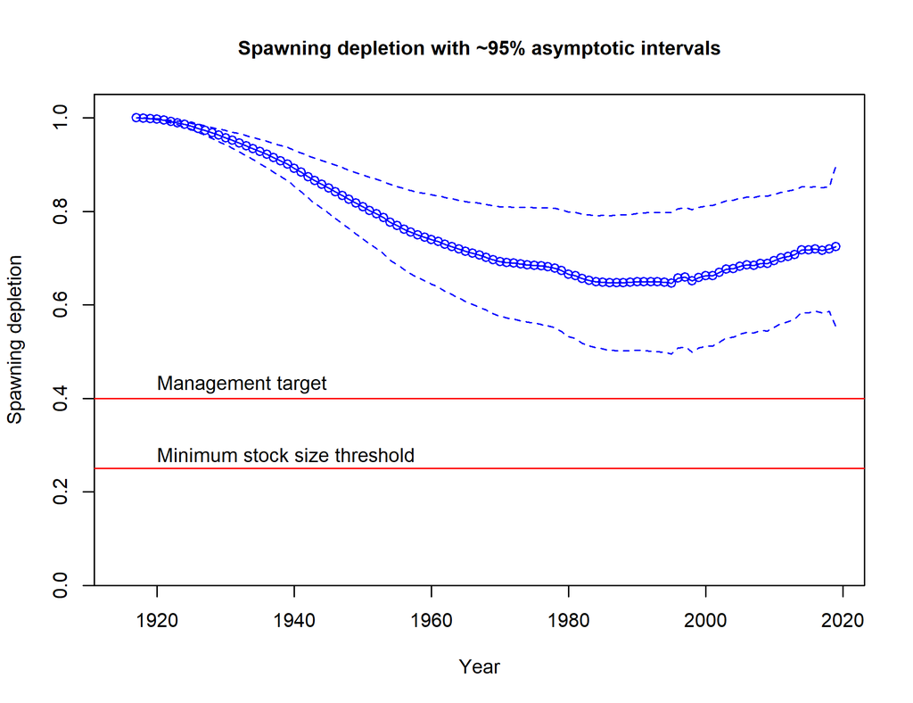

Estimated relative depletion with approximate 95% asymptotic confidence intervals (dashed lines) for the base case assessment model.

## Recruitment

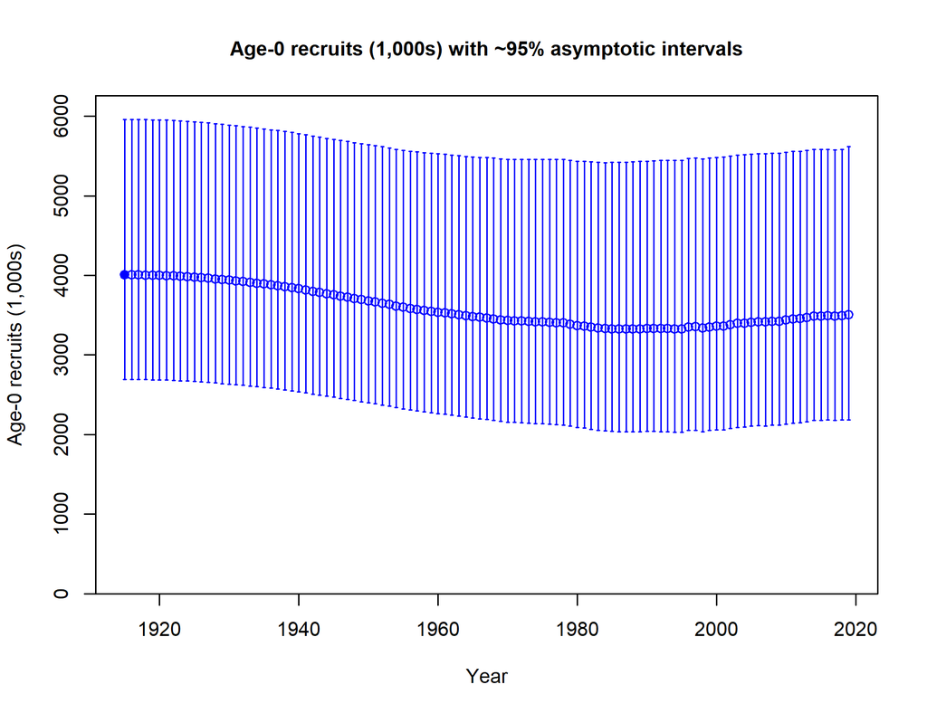

Time series of estimated Big Skate recruitments for the base-case model with 95% confidence or credibility intervals.

## Exploitation status

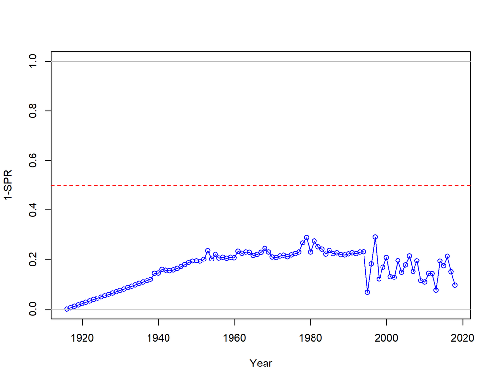

Estimated spawning potential ratio (SPR) for the base-case model. One minus SPR is plotted so that higher exploitation rates occur on the upper portion of the y-axis. The management target is plotted as a red horizontal line and values above this reflect harvests in excess of the overfishing proxy based on the SPR harvest rate. The last year in the time series is 2018.

## Ecosystem Considerations

In this assessment, ecosystem considerations were not explicitly included in the analysis.  
This is primarily due to a lack of relevant data and results of analyses (conducted elsewhere) that could contribute ecosystem-related quantitative information for the assessment.

## Unresolved Problems and Major Uncertainties

## Decision Table

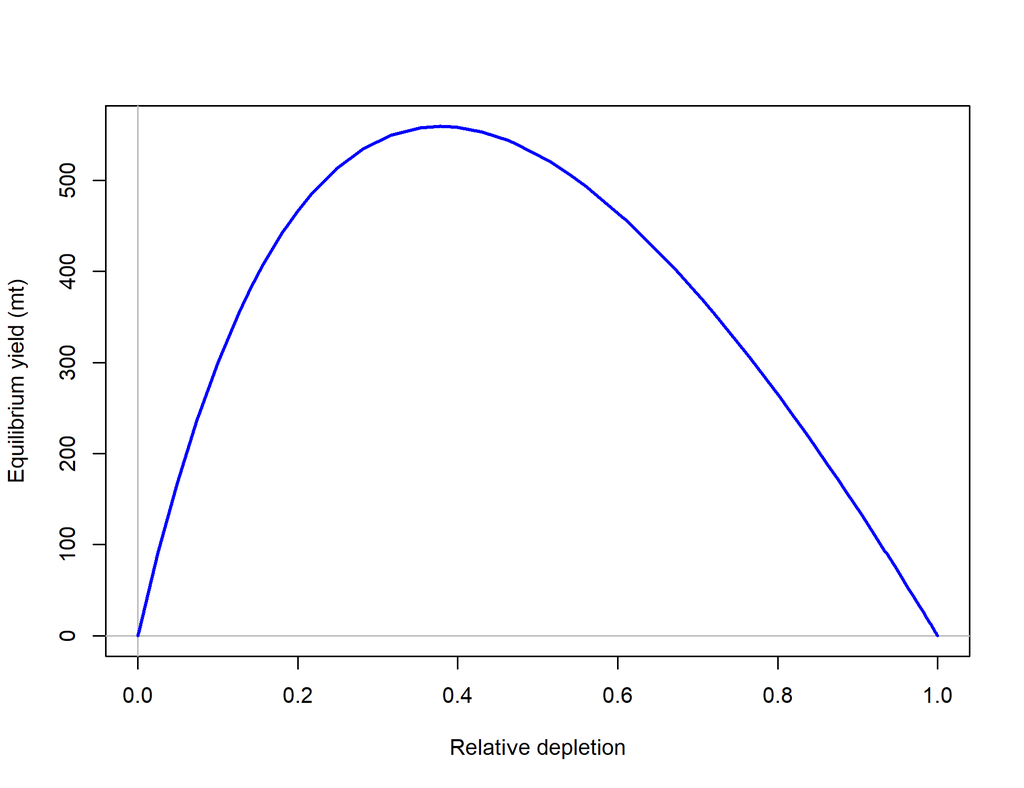

Equilibrium yield curve for the base case model. Values are based on the 2018 fishery selectivity and with steepness fixed at 0.718.

## Research and Data Needs

# Introduction

## Distribution and Life History

Skates are the largest and most widely distributed group of batoid fish with approximately 245 species ascribed to two families (Ebert and Compagno (2007), McEachran and Miyake (1990)). Skates are benthic fish that are found in all coastal waters but are most common in cold temperatures and polar waters (Ebert and Compagno 2007).

There are eleven species of skates in three genera (Amblyraja, Bathyraja, and Raja) present in the Northeast Pacific Ocean off California, Oregon and Washington (Ebert 2003). Of that number, just three species (Longnose Skate, *Raja rhina*; Big Skate, *Raja binoculata*; and Sandpaper Skate, *Bathyraja interrupta*) make up over 95 percent of West Coast Groundfish Bottom Trawl Survey (WCGBTS) catches in terms of biomass and numbers, with the Longnose Skate leading in both categories (with 62 percent of biomass and 56 percent of numbers).

Big Skate (*Raja binoculata*) is the largest of the skate species in North America with a documented maximum length of 244 cm total length and a maximum weight of 91 kg (Eschmeyer and Herald 1983). The species name “binoculata” (two-eyed) refers to the prominent ocellus at the base of each pectoral fin. Big Skates are usually seen buried in sediment with only their eyes showing.

The Big Skate is most common in soft-sediment habitats in coastal waters of the continental shelf (Bizzarro, JJ and Broms, KM and Logsdon, MG and Ebert, DA and Yoklavich, MM and Kuhnz, LA and Summers, AP (2014), Farrugia et al. (2016)). Use of mixed substrate (e.g., mud with boulders) increases with ontogeny but hard substrates are largely avoided (Bizzarro (2015)). In the GOA, the Big Skate is the most commonly encountered skate species in continental shelf waters at 100–200 m depth, and is most abundant in the central and western areas of the GOA (Stevenson, DE and Orr, JW and Hoff, GR and McEachran, JD (2008); Bizzarro, JJ and Broms, KM and Logsdon, MG and Ebert, DA and Yoklavich, MM and Kuhnz, LA and Summers, AP (2014)). Off the U.S. Pacific Coast, the Big Skate is most densely distributed on the inner continental shelf (< 100 m; Bizzarro, JJ and Broms, KM and Logsdon, MG and Ebert, DA and Yoklavich, MM and Kuhnz, LA and Summers, AP (2014)). Eggs are mainly deposited between 70–90 m on sand or mud substrates (Hitz (1964); NMFS-NWFSC-FRAM, unpub. data). Juveniles typically occur in shallower waters than adults (Bizzarro (2015)). Core habitat regions of Big Skate off the U.S. Pacific Coast and in the Gulf of Alaska are spatially segregated from those of other species (Bizzarro, JJ and Broms, KM and Logsdon, MG and Ebert, DA and Yoklavich, MM and Kuhnz, LA and Summers, AP (2014)).

Big Skates and their egg cases are preyed upon by a variety of vertebrates and invertebrates. Snails and other molluscs bore holes in egg cases to feed on developing embryos and especially their protein rich yolk-sacs (Bizzarro, pers. obs; Hoff, GR (2009)). Sevengill Sharks, Brown Rockfish, and Stellar Sea Lions are known predators of juvenile and adult Big Skates (Ebert (2003), Love, Milton S (2011)). Northern Sea Lions consume free-living Big Skates and their egg cases (Ebert (2003), Love, Milton S (2011)).

In 2012, the Big Skate was moved from genus *Raja* to the new genus *Beringraja* together with the Mottled Skate (*B. pulchra*) (Ishihara et al. 2012). These are the only two skates with multiple embryos per egg case, and they are very similar mophologically and genetically (Bizzarro, J. 2019).

## Biology

The Big Skate is broadly distributed, occurring from the southeastern Bering Sea (Mecklenburg, CW and Mecklenburg, TA and Thorsteinson, LK 2002) to southern Baja California (22.90º N, 110.03º W; (Castro-Aguirre et al. 1993)) and the Gulf of California (Castro-Aguirre and Pérez 1996). It has been reported at depths of 2–501 m (min: Miller et al. (1980); max: Farrugia et al. (2016)) but is most common on the inner continental shelf (< 100 m; (Love, Milton S 2011); (Bizzarro 2015)). Big Skates are highly mobile and capable of long range (> 2000 km) movements ((King and McFarlane 2009); (Farrugia et al. 2016)).

## Ecosystem Considerations

In this assessment, ecosystem considerations were not explicitly included in the analysis. This is primarily due to a lack of relevant data and results of analyses (conducted elsewhere) that could contribute ecosystem-related quantitative information for the assessment.

## Fishery Information

Big Skate are caught in commercial and recreational fisheries on the West Coast using line and trawl gears. There is a limited market for pectoral fins (skate wings).

The history of Big Skate is not well documented. They were used as a food source by the native Coastal and Salish Tribes (Batdorf, C 1990) long before Europeans settled in the Pacific Northwest and then as fertilizer by the settlers (Bowers, G. M. 1909). No directed fishery for Big Skate has been documented; rather, they were taken along with other skates and rays as “scrap fish” and used for fertilizer, fish meal and oil (Lippert 2019).

Skates have been regarded as a predator on desirable market species such as Dungeness crab, and were thought of as nuisance fish with no appeal as a food item save for small local markets. They had been discarded or harvested at a minimal level until their livers became valued along with those of other cartilaginous fishes for the extraction of vitamin A in the 1940s. Chapman (Chapman, W.M. 1944) recorded that “At present they are being fished heavily, in common with the other elasmobranchs of the coast, forthe vitamins in their livers. The carcasses are either thrown away at sea or made into fish meal. Little use is made of the excellent meat of the wings”.

Little information is available about the historic Washington fishery for Big Skate. In records before 2000, they are lumped together with other skates or in market categories (Lippert 2019); this necessitates considerable attention to reconstructing the fishery by observing the composition of skate catches in the modern fishery and applying those to the recently reconstructed historical records.

Very little information is known about the Big Skate historical fishery in Oregon. The information we do have is mainly from historical landing data and species composition samples starting in the mid-nineties. The bulk of the catch is from the bottom trawl and longline fisheries, with smaller amounts as by-catch in mid-water trawl and the shrimp trawl fishery. Big Skate was lumped into the nominal “Skate” category until 2015 when it was separated into its own market category. Species composition data have been vitally important in reconstructing the pre-2015 historical catch (Calavan 2019).

## Stock Status and Management History

Big Skate were managed in the “Other Fish” complex until 2015 when they were designated an Ecosystem Component (EC) species. Catches of Big Skate are estimated to have averaged 95 mt from 2007–2011, along with large landings of “Unspecified Skate”. Analysis of Oregon port-sampling data indicates that about 98 percent of the recent Unspecified Skate landings in Oregon were comprised of Big Skate. Such large landings indicates targeting of Big Skate has occurred and an EC designation was not warranted. Based on this evidence, Big Skate was redesignated as an actively-managed species in the fishery. Big skate have been managed with stock-specific harvest specifications since 2017.

The recent OFL of 541 mt was calculated by applying approximate MSY harvest rates toestimates of stock biomass from the Northwest Fisheries Science Center (NWFSC) West Coast Groundfish Bottom Trawl Survey. This survey-based biomass estimate is likely underestimated since Big Skate are distributed all the way to the shoreline and no West Coast trawl surveys have been conducted in water shallower than 55 meters. This introduces an extra source of uncertainty to management and suggests that increased precaution is needed to reduce the risk of overfishing the stock.

There has been consideration for managing Big Skate in a complex with Longnose Skate, the other actively-managed West Coast skate species, but the two species have disparate distributions and fishery interactions (Longnose Skate is much more deeply distributed than Big Skate) and that option was not endorsed. The Pacific Fishery Management Council has chosen to set the Annual Catch Limit (ACL) equal to the Allowable Biological Catch (ABC) with a buffer for management uncertainty (P*) of 0.45.

## Fisheries Off Alaska, Canada and Mexico

** Alaska **

In Alaska, skates were primarily taken as bycatch in both longline and trawl fisheries until 2003, when a directed skate fishery developed in the Gulf of Alaska, where Longnose and Big skates comprise the majority of the skate biomass.

The Gulf of Alaska (GOA) skate complex is managed as three units. Big skates and Longnose Skates each have separate harvest specifications, with acceptable biological catches (ABCs) specified for each GOA regulatory area (western, central, and eastern). A single gulfwide overfishing level (OFL) is specified for each stock. All remaining skate species are managed as an “Other Skates” group with gulfwide harvest specifications. All GOA skates are managed as Tier 5 stocks, where OFL and ABC are based on survey biomass estimates and natural mortality rate (Alaska Fisheries Science Center 2018).

In the Bering Sea and Aleutian Islands, skates are assessed as a group rather than as separate species.

** Canada **

In Canada historic information regarding skate catches goes back to the 1950’s. Prior to 1990’s skates were taken mostly as bycatch and landings were reported as part of a skate complex (not by species). As with the West Coast, the trawl fishery is responsible for the largest amount of bycatch. Skate catches off British Columbia accelerated in the early 1990’s, partly due to emerging Asian markets. Since 1996, longnose skate has been targeted by the B.C. trawl fishery and, as a result, catches have been more accurately reported.

Assessments of Longnose Skate and Big Skate were conducted by Canada’s Division of Fisheries and Oceans in 2015(King, J.R., Surry, A.M., Garcia, S., and P.J. Starr 2015). For Big Skate, a Bayesian surplus production model failed to provide plausible results, and two data-limited approaches were investigated: Depletion-Corrected Average Catch Analysis (DCAC), and a Catch-MSY (maximum sustainable yield) Approach.

DCAC produced a range of potential yield estimates that were above the long-term average catch, with an upper bound that was three orders of magnitude larger than the long-term average catch. The Catch-MSY approach was found to be quite sensitive to assumptions and was not recommended as the sole basis of advice to managers.

The recommendation for managment for both skate species was that they should be managed with harvest yeilds based on mean historic catch, with consideration given to survey trends and to the ranges of maximum sustainable yield estimates identified by the Catch-MSY Approach. However, the analysis found no significant trends in abundance indices for Big Skate, and mean historical catches were below the maximum MSY estimate from the catch-MSY results.

# Fishery Data

## Commercial Fishery Landings

### Catch reconstructions for WA, OR, and CA

Information for Big Skate is very limited, in part because the requirement to sort landings of Big Skate in the shore-based Individual Fishing Quota fishery from landings in the “Unidentified Skate” category was not implemented until June 2015. The historical catch of Big Skate therefore relies on the historical reconstruction of Longnose Skate.

For the 2019 assessment, a new approach has been developed for estimating the catch history for Longnose Skate based on a linear regression model that predicts the catch of Longnose Skate from the catch of Dover sole, for which historical catch estimates are available (Gertseva, V. 2019). The dependent variable for the linear regression model was the West Coast Groundfish Observer Program (WCGOP) annual estimates of the coastwide total catch (landings plus discards) of Longnose Skate for the period 2009 to 2017 and the independent variable was the corresponding WCGOP annual estimates of coastwide total catch (landings plus discards) of Dover sole. The regression model has good predictive power (R<sup>2</sup> = 95.7%) over the range of the Dover sole catches (6,500 to 12,500 mt).

The discard component of the catch reconstruction for Big Skate may be based either on the catch reconstruction for Longnose Skate and the assumption that the two species experience similar discard rates (discard / total catch) or on a similar analysis with links to species that co-occur with big skate. Data from the Pikitch discard study (1985-1987) and from WCGOP (2015-2017) support the idea that discard rates for the two species are very similar. Also, market demand for skates does not seem to distinguish between the two species. There are insufficient years of data from the WCGOP to develop a regression model for Big Skate as was done for Longnose Skate.

**Oregon Commercial Skate Landings Reconstruction**

Species compositions of skate complexes from commercial port sampling are available throughout this time period but are generally limited, which precluded the use of all strata for reconstructing landings. Quarter and port were excluded, retaining gear type, PMFC area, and market category for stratifying reconstructed landings within the three time blocks. Bottom trawl gear types include multiple bottom trawl gears, and account for greater than 98% of skate landings . Minor gear types include primarily bottom longline gear, but also include mid-water trawl, hook and line, shrimp trawl, pot gear and scallop dredge.

For bottom trawl gears, trawl logbook areas and adjusted skate catches were matched with strata-specific species compositions. In Time Block 1 (1978 – 2008), all bottom trawl gear types were aggregated due to a lack of specificity in the gear recorded on the fish tickets. However, in Time Blocks 2 and 3, individual bottom trawl gear types were retained. Some borrowing of species compositions was required (31% of strata) and when necessary, borrowed from the closest area or from the most similar gear type . Longline gear landings were reconstructed in a similar fashion as to bottom trawl and required some borrowing among strata as well (25%).

Due to insufficient species compositions, mid-water trawl landings were reconstructed using a novel depth-based approach. Available compositions indicate that the proportion by weight of big skates within a composition drops to zero at approximately 100 fathoms, and an inverse relationship is observed for longnose skate, where the proportion by weight is consistently one beyond 100 – 150 fathoms . Complex-level landings were assigned a depth from logbook entries and these species specific depth associations were used to parse out landings by species. The approach differed somewhat by time block . Landings from shrimp trawls were handled using a similar methodology. Finally, very minor landings from hook and line, pot gear and scallop dredges were assigned a single aggregated species composition, as they lack any gear-specific composition samples. Landings from within a time block were apportioned by year using the proportion of the annual ticket landings.

Results indicate that the species-specific landings from this reconstruction are very similar to those from Oregon’s commercial catch reconstruction (Karnowski et al. 2014) during the overlapping years but cover a greater time period with methodology more applicable to skates in particular. ODFW intends to incorporate reconstructed skate landings into PacFIN in the future (A. Whitman, ODFW; pers. comm.).

**California Catch Reconstruction**

A reconstruction of historical skate landings from California waters was developed for the 1916–2017 time period using a combination of commercial catch data (spatially explicit block summary catches and port sample data from 2009-2017) and fishery-independent survey data (Bizzarro, J. 2019). Virtually all landings in California were of “unspecified skate” until species-composition sampling of skate market categories began in 2009.

From 2009 through 2017, catch estimates were based on these market category species-composition samples, and the average of those species-compositions was hindcast to 2002, based on the assumption that those data were representative of the era of large area closures in the post-2000 period.

For the period from 1936-1980, spatially explicit landings data (the California Department of Fisheries and Wildlife (CDFW) block summary data) were merged with survey data to provide species-specific estimates.

For years 1981-2001, a “blended” product of these two approaches was taken, in which a linear weighting scheme blended the two sets of catch estimates through that period. Landings estimates were also scaled upwards by an expansion factor for skates landed as “dressed” based on fish ticket data. Prior to 1981 these data had not been reported and skate landings were scaled by the “average” percentage landed as dressed in the 1981-1985 time period, but by the late 1980s nearly all skates were landed round.

As no spatial information on catch is available from 1916-1930, and the block summary data were very sparse in the first few years of the CDFW fish ticket program (1931–1934), spatial information from the late 1930’s was used to hindcast to the 1916–1935 time period.

### Tribal Catch in Washington

### Commercial Discards

Commercial discards of Big Skate are highly uncertain. The method used to estimate discards for Longnose Skate was based on a strong correlation between total mortality of that species, and total mortality of Dover Sole for the years 2009–2017 during which Longnose were landed separately from other skates. In contrast, the sorting requirement for Big Skate occurred too recently to provide an adequate range of years for this type of correlation. Furthermore, there is greater uncertainty in the total mortality for the shallow-water species with which Big Skate most often co-occurs, such as Sand Sole and Starry Flounder, than there is for Dover Sole, which has been the subject of recurring stock assessments.

### Fishery-Independent Data Sources

**Alaska Fisheries Science Center (AFSC) Triennial Shelf Survey**  
Research surveys have been used since the 1970s to provide fishery-independent information about the abundance, distribution, and biological characteristics of Big Skate. A coast-wide survey was conducted in 1977 (Gunderson, Donald Raymond and Sample, Terrance M. 1980) by the Alaska Fisheries Science Center, and repeated every three years through 2001. The final year of this survey, 2004, was conducted by the NWFSC according to the AFSC protocol. We refer to this as the **Triennial Survey**.

The survey design used equally-spaced transects from which searches for tows in a specific depth range were initiated. The depth range and latitudinal range was not consistent across years, but all years in the period 1980-2004 included the area from 40$^\circ$ 10’N north to the Canadian border and a depth range that included 55-366 meters, which spans the range where the vast majority of Big Skate encountered in all trawl surveys. Therefore the index was based on this depth range. The survey as conducted in 1977 had incomplete coverage and is not believe to be comparable to the later years, and is not used in the index.

**Northwest Fisheries Science Center West Coast Groundfish Bottom Trawl Survey**

The data from the NWFSC Combo survey was analyzed using a spatio-temporal delta-model (Thorson, J. T. and Shelton, A. O. and Ward, E. J. and Skaug, H. J. 2015), implemented as an R package VAST (Thorson, James T. and Barnett, Lewis A. K. 2017) and publicly available online (https://github.com/James-Thorson/VAST). Spatial and spatio-temporal variation is specifically included in both encounter probability and positive catch rates, a logit-link for encounter probability, and a log-link for positive catch rates. Vessel-year effects were included for each unique combination of vessel and year in the database.

**Internation Pacific Halibut Commission Longline Survey**

The IPHC has conducted an annual longline survey for Pacific Halibut off the coast of Oregon and Washington since 1997 (no surveys were performed in 1998 or 2000). Beginning in 1999, this has been a fixed station design, with 84 locations in this area (station locations differed in 1997, and are therefore not comparable with subsequent surveys). 400 to 800 hooks have been deployed at each station in 100-hook groups (typically called “skates” although that term will be avoided here to avoid confusion). The gear used to conduct the survey was designed to efficiently sample Pacific Halibut and used 16/0 (#3) circle hooks baited with Chum Salmon.

In some years from 2011 onward, additional stations were added to the survey to sample Yelloweye Rockfish. These stations were excluded from the analysis, as were additional stations added in 2013, 2014, and 2017, off the coast of California (south of 42 degrees latitude). Some variability in exact sampling location is practically unavoidable, and leeway is given in the IPHC methods to center the set on the target coordinates while allowing wind and currents to dictate the actual direction in which the gear is deployed. This can result in different habitats being accessed at each fixed deployment location across years. One station that was very close to the U.S. Canada border had the mid-point of the set in Canada in 2 out of the 19 years of the survey. For consistency among years, all samples from this station were included in the analysis, including those in Canada.

### Biological Parameters and Data

**Measurement Details and Conversion Factors**

Disc width to total length (estimated by Ian on Apr 15, similar to Ebert 2008 estimates for Alaska) L = 1.3399 * W estimated from 95 samples from WCGBTS where both measurements collected (R-squared = 0.9983). Little sex difference observed, so using single relationship for both sexes. Inter-spiracle width to total length from Downs & Cheng (2013): L = 12.111 + 9.761*ISW (females) L = 3.824 + 10.927*ISW (males)

**Length and Age Compositions**

Length comps (some based on widths)

WCGBTS Lengths from all years except 2006 and 2007 Widths in 2006 and 2007

Commercial fisheries In process Discard comps from 2010-2015

The length composition of all fisheries aggregated across time by fleet is in Figure . Descriptions and details of the length composition data are in the above section for each fleet or survey.

**Age Structures**

von Bertalanffy growth curve (von Bertalanffy, L 1938), $L_i = L_{\infty}e^{(-k[t-t_0])}$, where $L_i$ is the length (cm) at age $i$, $t$ is age in years, $k$ is rate of increase in growth, $t_0$ is the intercept, and $L_{\infty}$ is the asymptotic length.

Triennial Survey No ages

Commercial fisheries 2009 samples from WA were stratified by length, so should be treated as conditionals

**Aging Precision and Bias**

**Weight-Length**

**Sex Ratio, Maturity, and Fecundity**

**Natural Mortality**

The Hamel prior for M is lognormal(ln(5.4/max age),.438), which based on 1 age-15 fish out of 1034 observed in the WCGBTS results in lognormal( -1.021651, 0.438)

If it needs to be fixed, it should be set to M = 5.4/max age = 5.4/15 = 0.36

### Environmental or Ecosystem Data Included in the Assessment

In this assessment, neither environmental nor ecosystem considerations were explicitly included in the analysis. This is primarily due to a lack of relevant data and results of analyses (conducted elsewhere) that could contribute ecosystem-related quantitative information for the assessment.

# Assessment

## Previous Assessments

### History of Modeling Approaches Used for this Stock

Deriving estimates of OFL for species in the “Other Fish” complex or potential alternative complexes

The current “Other Fish” complex and proposed alternatives include a number of species for which estimates of OFL contributions are not available from stock assessments or data-poor methods. Four of the species had OFL contributions for the 2013–2014 management cycle calculated by applying approximate MSY harvest rates to estimates of stock biomass from the NWFSC West Coast Bottom Trawl Survey (Bradburn et al., 2012). This approach is described in detail in Cope et al. (2012).

## Model Description

### Estimated and Fixed Parameters

*Growth.*

*Natural Mortality.*

*Selectivity.*

*Other Estimated Parameters.*

*Other Fixed Parameters.*

## Model Selection and Evaluation

### Key Assumptions and Structural Choices

### Alternate Models Considered

### Convergence

## Response to the Current STAR Panel Requests

## Base Case Model Results

### Parameter Estimates

The additional survey variability (process error added directly to each year’s input variability) for all surveys was estimated within the model.

### Retrospective Analysis

### Likelihood Profiles

### Reference Points

# Harvest Projections and Decision Tables

# Regional Management Considerations

# Research Needs

# Acknowledgments

The authors gratefully acknowledge the time and effort reviewers Stacey Miller, Jim Hastie and Owen Hamel put into making this a polished document.

# Tables

## Data Tables

## Model Results Tables

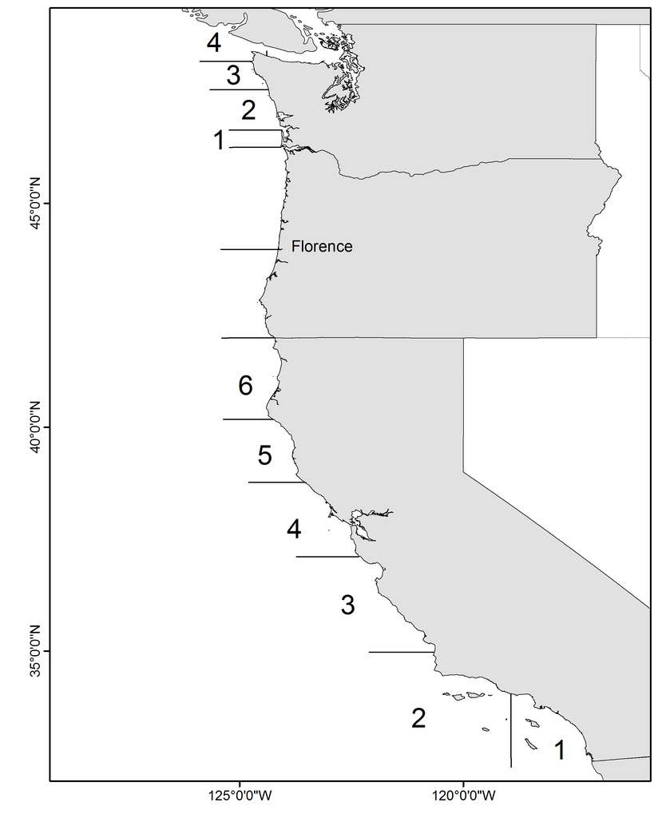

Map showing the state boundary lines for management of the recreational fishing fleets

[figure not shown]

Summary of data sources used in the model.

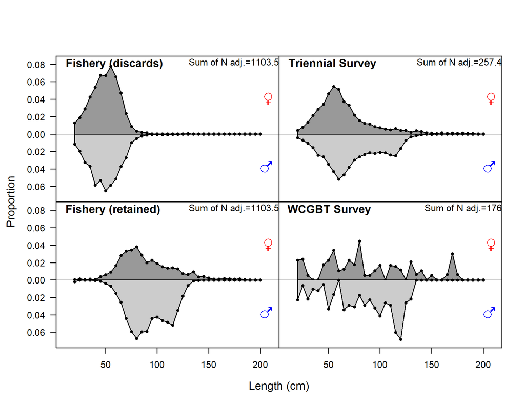

Length comp data, aggregated across time by fleet. Labels ‘retained’ and ‘discard’ indicate discarded or retained sampled for each fleet. Panels without this designation represent the whole catch.

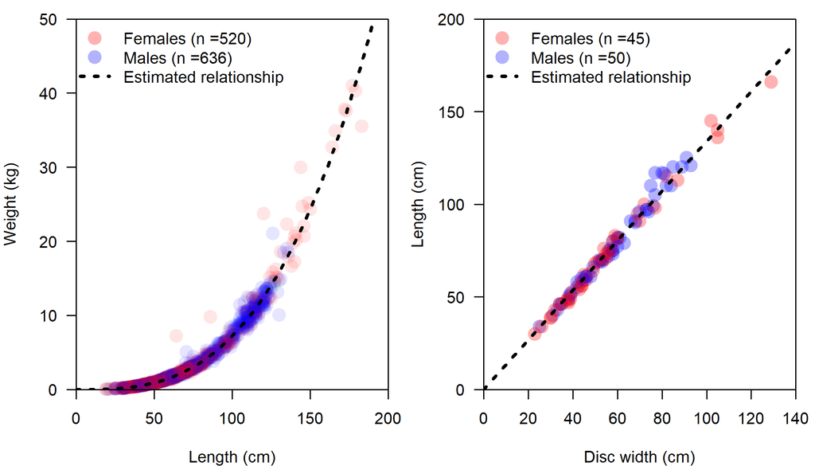

Estimated relationship between length and weight (left) and disc-width and length (right) for Big Skate. Colored points show observed values and the black line indicates the estimated relationship $W = 0.0000074924L^{2.9925}$.